# Iterative Prediction of Survival and hyperparameter tuning

Reinhard Sellmair

Last update on 10.6.2018: added Random Forest Classifier

# 1 Introduction

In this kernel I’m predicting the survival of passengers on the Titanic. In contrast to most other kernels I’m using the survival information of other passengers as feature. Therewith, survival information of all passengers’ relatives which were on board is taken into account. Obviously, since the survival of not all passengers is known I propose an iterative process where the survival features are updated after each prediction iteration.

I start with logistic regression and will add different classifier in future versions of this kernel. For each classifier I do some hyper-parameter tuning in order to obtain the best results.

# 2 Preparation

## 2.1 Loading of data

I described the extraction of family relations and the feature engineering in [Save the Families!](https://www.kaggle.com/reisel/save-the-families) and [Imputation and Feature Engineering](https://www.kaggle.com/reisel/imputation-and-feature-engineering/notebook).

```r
# load packages
library(dplyr)
library(knitr)
library(kableExtra)
library(ggplot2)

# logistic regression with regularisation
library(glmnet)
# knn classifier
library(FNN)
# naive bayes classifier and SVM
library(e1071)
# decision tree
library(rpart)
# random foreset
library(randomForest)
```

```r
# load data
passenger <- read.csv("../input/imputation-and-feature-engineering/passenger.csv")

# change data types
passenger$Name <- as.character(passenger$Name)
passenger$Ticket <- as.character(passenger$Ticket)
passenger$Cabin <- as.character(passenger$Cabin)
passenger$Surname <- as.character(passenger$Surname)
passenger$MaidenName <- as.character(passenger$MaidenName)
passenger$Firstname <- as.character(passenger$Firstname)
passenger$SiblingId <- as.character(passenger$SiblingId)
passenger$ChildrenId <- as.character(passenger$ChildrenId)
passenger$ParentsId <- as.character(passenger$ParentsId)
passenger$HusbandFirstname <- as.character(passenger$HusbandFirstname)
passenger$SiblingId <- as.list(passenger$SiblingId)
passenger$ChildrenId <- as.list(passenger$ChildrenId)
passenger$ParentsId <- as.list(passenger$ParentsId)
passenger$SameTicketId <- as.list(passenger$SameTicketId)

# remove "X" column
passenger <- select(passenger, -X)

# convert passenger ids of relatives from character to lists of integers
for (i in 1:dim(passenger)[1]){
    passengerSelect <- passenger[i, ]

    # convert sibling ids
    if (!is.na(passengerSelect$SiblingId)){
        passengerSelect$SiblingId <- list(as.numeric(unlist(strsplit(passengerSelect$SiblingId[[1]], ";"))))
    } else {
        passengerSelect$SiblingId <- NA
    }
    # convert children ids
    if (!is.na(passengerSelect$ChildrenId)){
        passengerSelect$ChildrenId <- list(as.numeric(unlist(strsplit(passengerSelect$ChildrenId[[1]], ";"))))
    } else {
        passengerSelect$ChildrenId <- NA
    }
    # convert parents ids
    if (!is.na(passengerSelect$ParentsId)){
        passengerSelect$ParentsId <- list(as.numeric(unlist(strsplit(passengerSelect$ParentsId[[1]], ";"))))
    } else {
        passengerSelect$ParentsId <- NA
    }
    # convert same ticket id
    if (!is.na(passengerSelect$SameTicketId)){
        passengerSelect$SameTicketId <- list(as.numeric(unlist(strsplit(as.character(passengerSelect$SameTicketId[[1]]), ";"))))
    } else {
        passengerSelect$SameTicketId <- NA
    }

    passenger[i, ] <- passengerSelect
}
```

This data set contains many columns which were only used for its construction. To have a more tidy set, I keep only the columns which I use for the prediction.

```r
# remove columns
passenger <- select(passenger, -c(Name,
                                  Ticket,
                                  Fare,
                                  Cabin,
                                  Embarked,
                                  Surname,
                                  MaidenName,
                                  Firstname,
                                  HusbandFirstname,
                                  SiblingAgeMin,
                                  SiblingAgeMax,
                                  SiblingAgeMean,
                                  ParentAgeMin,
                                  ParentAgeMax,
                                  ParentAgeMean,
                                  ChildrenAgeMin,
                                  ChildrenAgeMax,
                                  ChildrenAgeMean,
                                  SameTicketAgeMin,
                                  SameTicketAgeMax,
                                  SameTicketAgeMean,
                                  SpouseAge,
                                  CabinNr))

# add feature about survival of passengers with same ticket
passenger$SameTicketSurvivedDiff <- NA
```

## 2.2 Helper functions

Next, I create several functions which are later used for the data handling.

First, I create a function which is used to update the passengers’ survival features (SpouseSurvivedDiff, SiblingSurvivedDiff, ChildrenSurvivedDiff, ParentsSurvivedDiff, FatherSurvivedDiff, MotherSurvivedDiff, RelativesSurvivedDiff, and SameTicketSurvivedDiff) with respect to the prediction. These features contain the difference of survived minus not survived relatives, e.g. if a passenger’s spouse survived its value is 1, if he or she didn’t survived its -1 and if the passengers didn’t have a spouse aboard, the value is 0. If the spouse’s survival is not known (because the passenger is in the test data set), the value is NA.

```r
# function to update survival features of all passengers
updateSurvivalFeatures <- function(passenger){
    # number of passengers
    nPassenger <- dim(passenger)[1]
    # transform survived feature to -1 or 1
    survived <- passenger$Survived * 2 - 1
    # set survival differences to NA
    passenger$SameTicketSurvivedDiff <- NA
    passenger$SpouseSurvivedDiff <- NA
    passenger$SiblingSurvivedDiff <- NA
    passenger$ChildrenSurvivedDiff <- NA
    passenger$ParentsSurvivedDiff <- NA
    passenger$FatherSurvivedDiff <- NA
    passenger$MotherSurvivedDiff <- NA

    for (iPassenger in 1:nPassenger){
        passengerSelect <- passenger[iPassenger, ]

        # survival of spouse
        if (passengerSelect$SpouseNumber == 1){
            passengerSelect$SpouseSurvivedDiff <- survived[passengerSelect$SpouseId]
        } else {
            passengerSelect$SpouseSurvivedDiff <- 0
        }

        # survival of siblings
        passengerSelect$SiblingSurvivedDiff <-
            sum(survived[passenger$PassengerId %in% unlist(passengerSelect$SiblingId)])

        # survival of children
        passengerSelect$ChildrenSurvivedDiff <-
            sum(survived[passenger$PassengerId %in% unlist(passengerSelect$ChildrenId)])

        # survival of parents
        passengerSelect$ParentsSurvivedDiff <-
            sum(survived[passenger$PassengerId %in% unlist(passengerSelect$ParentsId)])

        # survival of passengers with same ticket
        passengerSelect$SameTicketSurvivedDiff <-
            sum(survived[passenger$PassengerId %in% unlist(passengerSelect$SameTicketId)])

        # survival of mother and father
        if (passengerSelect$ParentsNumber > 0){
            # get parents
            parents <- passenger[passenger$PassengerId %in% unlist(passengerSelect$ParentsId), ]
            # survival of father
            if (passengerSelect$FatherNumber == 1){
                father <- parents[parents$Sex == 'male', ]
                passengerSelect$FatherSurvivedDiff <- father$Survived * 2 - 1
            } else {
                passengerSelect$FatherSurvivedDiff <- 0
            }
            # survival of mother
            if (passengerSelect$MotherNumber == 1){
                mother <- parents[parents$Sex == 'female', ]
                passengerSelect$MotherSurvivedDiff <- mother$Survived * 2 - 1
            } else {
                passengerSelect$MotherSurvivedDiff <- 0
            }
        } else {
            passengerSelect$ParentsSurvivedDiff <- 0
            passengerSelect$FatherSurvivedDiff <- 0
            passengerSelect$MotherSurvivedDiff <- 0
        }

        # insert selected passenger into passenger set
        passenger[iPassenger, ] <- passengerSelect
    }

    # survival of relatives
    passenger$RelativesSurvivedDiff <-
        passenger$SpouseSurvivedDiff +
        passenger$SiblingSurvivedDiff +
        passenger$ChildrenSurvivedDiff +
        passenger$ParentsSurvivedDiff

    passenger
}

passenger <- updateSurvivalFeatures(passenger)
```

This function is used to do k-fold validation by splitting the passenger data set into training, validation, and test sets. The test set consits of the same passengers as in the original data.

```r
# function to split data into n sets of training and validation data
nSplitData <- function(data, dataTest, n){
    # number of observations
    nData <- dim(data)[1]
    dataSplit <- vector("list", n)
    # number of samples per split
    nSampleSplit <- round(nData / n)

    for (iSplit in 1:(n-1)){
        iSelect <- vector(, nData)
        # sample elements
        indexSelect <- sample(nData, nSampleSplit)
        iSelect[indexSelect] <- TRUE

        # move data into split set
        dataSplit[[iSplit]] <- data[iSelect, ]

        # remove split set from data
        data <- data[!iSelect, ]
        nData <- nData - nSampleSplit
    }

    # add remaining data to split set
    dataSplit[[n]] <- data

    # combine splitted data to training and validation sets
    training <- vector("list", n)
    validation <- vector("list", n)

    for (iSet in 1:n){
        indexSelect <- 1:n
        indexSelect <- indexSelect[indexSelect != iSet]
        training[[iSet]] <- dataSplit[[indexSelect[1]]]
        validation[[iSet]] <- dataSplit[[iSet]]
        for (iAdd in indexSelect[2:n]){
            training[[iSet]] <- rbind(training[[iSet]], dataSplit[[iAdd]])
        }
        # relabel data set of validation data
        validation[[iSet]]$DataSet <- as.factor("Validation")

        # order data sets by passenger id
        training[[iSet]] <- training[[iSet]][order(training[[iSet]]$PassengerId), ]
        validation[[iSet]] <- validation[[iSet]][order(validation[[iSet]]$PassengerId), ]
    }

    # return training and validation data
    list("training" = training, "validation" = validation, "test" = rep(list(dataTest[order(dataTest$PassengerId), ]), n))
}
```

This function is used to update the survival feature in the validation and test sets with respect to the passengers’ predicted survival.

```r
updateSurvivalPerSet <- function(dataSet, prediction){

    # number of sets
    nSet <- length(dataSet$training)

    # check if validation data exists
    valExists <- !is.null(dataSet$validation)

    for (iSet in 1:nSet){
        # get training, validation, and test sets
        training <- dataSet$training[[iSet]]
        test <- dataSet$test[[iSet]]
        if (valExists){
            validation <- dataSet$validation[[iSet]]
        } else{
            validation <- NULL
        }

        # add predicted survival to validation and training data set
        test$Survived <- prediction$test[[iSet]]

        # combine data sets to passenger data set
        passengerSet <- rbind(training, validation, test)
        # sort by passenger ID
        passengerSet <- passengerSet[order(passengerSet$PassengerId), ]

        # update survival features
        passengerSet <- updateSurvivalFeatures(passengerSet)

        # split data set again into training, validation, and test data sets
        dataSet$training[[iSet]] <- passengerSet[passengerSet$DataSet == "Training", ]
        dataSet$test[[iSet]] <- passengerSet[passengerSet$DataSet == "Test", ]

        # process validation data
        if (valExists){
            validation$Survived <- prediction$validation[[iSet]]
            dataSet$validation[[iSet]] <- passengerSet[passengerSet$DataSet == "Validation", ]
        }
    }

    dataSet
}
```

The following function is doing the one-hot encoding of features, which I apply to the features: Sex, Title, Deck, and CabinSide.

```r
hotEncodeFeature <- function(trainingData, validationData, testData){
    # hot encode categorical features
    # names of features to be encoded
    featureEncode <- c("Sex", "Title", "Deck", "CabinSide")

    # check if validation data is given
    valExists <- !is.null(validationData)


    # number of sets
    nSet <- length(trainingData)
    for (iSet in 1:nSet){

        # get data sets
        training <- trainingData[[iSet]]
        test <- testData[[iSet]]
        if (valExists){validation <- validationData[[iSet]]}

        for (feature in featureEncode){
            # get values of feature
            values <- as.character(unique(training[, feature]))
            for (value in values){
                # create feature name
                newFeatureName <- paste0(feature, "_", value)
                # populate feature for training, validation, and test data
                training[, newFeatureName] <- training[, feature] == value
                test[, newFeatureName] <- test[, feature] == value
                if (valExists){validation[, newFeatureName] <- validation[, feature] == value}
            }
        }
        # remove original feature from dataframe
        training <- training[, !(names(training) %in% featureEncode)]
        test <- test[, !(names(test) %in% featureEncode)]
        if (valExists){validation <- validation[, !(names(validation) %in% featureEncode)]}

        # insert new sets
        trainingData[[iSet]] <- training
        testData[[iSet]] <- test
        if (valExists){validationData[[iSet]] <- validation}
    }
    list('training' = trainingData, 'validation' = validationData, 'test' = testData)
}
```

The next function normalises the data sets. Thereby, the parameters for normalisation are exclusively calculated for the training set while these parameters are also used to normalise the validation and test set.

```r
# normalise data sets
normaliseFeature <- function(trainingSet, validationSet, testSet){
    # number of sets
    nSet <- length(trainingSet)

    # check if validation data exists
    valExists <- !is.null(validationSet)

    # names of features to be excluded from normalisation
    featureExclude <- c("PassengerId", "Survived", "DataSet", "SpouseId", "SiblingId", "ChildrenId", "ParentsId", "SameTicketId")

    for (iSet in 1:nSet){
        # get data sets
        training <- trainingSet[[iSet]]
        test <- testSet[[iSet]]
        if (valExists){validation <- validationSet[[iSet]]}

        # get feature names to be normalised
        featureNorm <- names(training)[!(names(training) %in% featureExclude)]

        for (feature in featureNorm){
            # check if feature contains NAs
            if (any(is.na(training[, feature]))){
                # feature cannot be normalised
                next
            }

            # get maximum and minimum feature values
            featureMax <- max(training[, feature])
            featureMin <- min(training[, feature])

            # check if feauture need to be normed
            if (featureMin == 0 & featureMax == 1){
                # feature does not need to be normed
                next
            }

            # get range of feature
            featureRange <- featureMax - featureMin
            # check if range is 0
            if (featureRange == 0){
                # normalisation not possible - set all values to 0
                training[, feature] <- 0
                test[, feature] <- 0
                if (valExists){validation[, feature] <- 0}
                next
            }

            # normalise feature
            training[, feature] <- (training[, feature] - featureMin) / featureRange
            test[, feature] <- (test[, feature] - featureMin) / featureRange
            if (valExists){validation[, feature] <- (validation[, feature] - featureMin) / featureRange}
        }
        # insert new sets
        trainingSet[[iSet]] <- training
        testSet[[iSet]] <- test
        if (valExists){validationSet[[iSet]] <- validation}
    }
    list('training' = trainingSet, 'validation' = validationSet, 'test' = testSet)
}
```

# 3 Prediction

It is a bit tricky to include the survival information of relatives as features as obviously the survival of not all passengers is knwon. Therefore, I make one prediction without these features, use the predicted survival to update all features and then make the predictions with the survival features. Next, I compare the initial prediction with the new prediction and check if there were any changes. If so I repeat this process as long as there are no more changes between the previous and the last prediction.

The following function is used to check if a prediction is equal to any prediction of a previous iteration.

```r
# function to check if prediction is equal to one element of set of predictions
isPredictionEqual <- function(prediction, predictionSet){

    # number of prediction sets
    nPred <- length(predictionSet)
    # number of data sets
    nSet <- length(prediction$test)
    # check if validation data exists
    valExists <- is.null(prediction$validation)

    # compare prediction
    for (iPred in 1:nPred){
        predictionComp <- predictionSet[[iPred]]

        predEqual <- TRUE

        # compare data set
        for (iSet in 1:nSet){
            if ((valExists && any(prediction$validation[[iSet]] != predictionComp$validation[[iSet]])) ||
                any(prediction$test[[iSet]] != predictionComp$test[[iSet]])) {
                predEqual <- FALSE
                break
            }
        }
        if (predEqual) {
            return(TRUE)
        }
    }
    FALSE
}
```

The accuracy of the survival prediction is calculated via the following function:

```r
# calculate accuracy of prediction based on validation data
predictionAccuracy <- function(prediction, survivalTrain, survivalVal){

    # number of data sets
    nSet <- length(prediction$train)

    accuracyTrain <- rep(NA, nSet)
    for (iSet in 1:nSet){
        accuracyTrain[iSet] <- mean(prediction$train[[iSet]] == survivalTrain[[iSet]])
    }

    # check if validation data exists
    if (!is.null(prediction$validation)){

        accuracyVal <- rep(NA, nSet)

        for (iSet in 1:nSet){
            accuracyVal[iSet] <- mean(prediction$validation[[iSet]] == survivalVal[[iSet]])

        }
    } else{
        accuracyVal <- NULL
    }

    list("train" = accuracyTrain, "val" = accuracyVal)
}
```

To evaluate the predictor’s accuarcy, I use cross-validation.

## 3.1 Logistic Regression

I use logistic regression with regularisation to avoid overfitting. The parameter alpha can be set between 0 and 1 and combines L1 penalty (lasso regression) and L2 penalty (ridge regression) regularisation whereby a value of 0 means that pure L2 penalty is used while pure L1 penalty is used if alpha is set to 1. In order to keep things simple I only use values of 0 or 1. The parameter lambda regulates the effect of the penalty on the loss function. The higher its value the stronger the effect of the penalty. Higher penalties force the optimisation to reduce the absolut value of the weights, which in turn reduces the variance of the model.

```r
# function to fit logistic regression model
fitModel <- function(X, y, p1, p2){
    glmnet(X, y, family = "binomial", alpha = p1, lambda = p2, standardize = FALSE)
}

# function to use model to predict survival
modelPredict <- function(model, X){
    as.numeric(predict(model, X, type = "class"))
}

# this function predicts the survival without using any survival features
predictionSurvival <- function(dataSet, alpha, lambda, initialPrediction = TRUE){
    # number of sets
    nSet <- length(dataSet$training)
    # check if validation data exists
    valExists <- !is.null(dataSet$validation)

    # initialise predicted variables
    yTrainPred <- vector("list", nSet)
    yValPred <- vector("list", nSet)
    yTestPred <- vector("list", nSet)

    if (initialPrediction){
        # features to be excluded from initial prediction
        featureExclude <- c("PassengerId",
                            "Survived",
                            "DataSet",
                            "SpouseId",
                            "SpouseSurvivedDiff",
                            "SiblingId",
                            "SiblingSurvivedDiff",
                            "ChildrenId",
                            "ParentsId",
                            "ChildrenSurvivedDiff",
                            "ParentsSurvivedDiff",
                            "FatherSurvivedDiff",
                            "MotherSurvivedDiff",
                            "RelativesSurvivedDiff",
                            "SameTicketId",
                            "SameTicketSurvivedDiff")
    } else {
        # features to be excluded from prediction with survival information
        featureExclude <- c("PassengerId",
                            "Survived",
                            "DataSet",
                            "SpouseId",
                            "SiblingId",
                            "ChildrenId",
                            "ParentsId",
                            "SameTicketId")
    }

    for (iSet in 1:nSet){
        # get data sets
        training <- dataSet$training[[iSet]]
        test <- dataSet$test[[iSet]]

        # get target values
        yTrain <- data.matrix(training$Survived)
        # get all features for prediction
        XTrain <- data.matrix(training[, !(names(training) %in% featureExclude)])
        XTest <- data.matrix(test[, !(names(training) %in% featureExclude)])

        # predict survival with logistics regression with regularisation
        model <- fitModel(XTrain, yTrain, alpha, lambda)

        # predict survival of test, validation and test set
        yTrainPred[[iSet]] <- modelPredict(model, XTrain)
        yTestPred[[iSet]] <- modelPredict(model, XTest)

        # process validation data set and predict if existing
        if (valExists){
            validation <- dataSet$validation[[iSet]]
            yVal <- data.matrix(validation$Survived)
            XVal <- data.matrix(validation[, !(names(training) %in% featureExclude)])
            yValPred[[iSet]] <- modelPredict(model, XVal)
        } else{
            yValPred <- NULL
        }
    }

    list("train" = yTrainPred, "validation" = yValPred, "test" = yTestPred)
}
```

The next function executes the whole pipeline from splitting the data set to one-hot encoding, normalising, predicting and updating of the survival features. This procedure is repeated as long as new predictions are different to all predictions of all previous iterations.

```r
# function to preprocess data set and run prediction

predictSurvIt <- function (passenger, p1, p2, nFold = 5, iMax = 10){
    # update survival features of passenger data set
    passenger <- updateSurvivalFeatures(passenger)

    # split passenger data set into training and test set
    trainingSet <- passenger[passenger$DataSet == "Training", ]
    testSet <- passenger[passenger$DataSet == "Test", ]

    # check if data shall be splitted
    if (nFold > 0){
        data <- nSplitData(trainingSet, testSet, nFold)

       # copy survival information of validation data set to calculate accuracy of applied models later
        survivedValOrg <- vector("list", nFold)
        survivedTrain <- vector("list", nFold)
        for (i in 1:nFold){
            survivedValOrg[[i]] <- data$validation[[i]]$Survived
            survivedTrain[[i]] <- data$train[[i]]$Survived
        }
    } else{
        data <- list("training" = list(trainingSet), "validation" = NULL, "test" = list(testSet))
        survivedValOrg <- NULL
        survivedTrain <- trainingSet$Survived
    }

    # hot-encoding
    encodeData <- hotEncodeFeature(data$training, data$validation, data$test)
    # normalisatin
    normData <- normaliseFeature(encodeData$training, encodeData$validation, encodeData$test)
    # make initial predict without survival features
    prediction <- predictionSurvival(normData, p1, p2, initialPrediction = TRUE)
    initialPrediction <- prediction

    predictionAll <- vector("list", iMax + 1)
    predictionAll[[1]] <- prediction

    # iteratively predict survival with survival features
    for (i in 1:iMax){
        # update survival features
        data <- updateSurvivalPerSet(data, prediction)

        # make new prediction
        oldPrediction <- prediction
        # hot-encoding
        encodeData <- hotEncodeFeature(data$training, data$validation, data$test)
        # normalisatin
        normData <- normaliseFeature(encodeData$training, encodeData$validation, encodeData$test)
        # predict with survival features
        prediction <- predictionSurvival(normData, p1, p2, initialPrediction = FALSE)

        # check if prediction changed
        predictionAll[[i + 1]] <- prediction
        if (isPredictionEqual(prediction, predictionAll[1:i])){
            # last iteration did not change any prediction - algorithm has converged
            break
        }
    }
    finalPrediction <- prediction

    # return inital, final prediction, and validation data
    list("initial" = initialPrediction, "final" = finalPrediction, "survivalVal" = survivedValOrg, "survivalTrain" = survivedTrain)
}
```

As an example I split the data into five folds and make a prediction for alpha = 0 and lambda = 0.05 and calculate the accuracy.

```r
# run prediction for alpha = 0 and lambda = 0.05
set.seed(0)
prediction <- predictSurvIt(passenger, p1 = 0, p2 = 0.05)

accuracyInitial <- predictionAccuracy(prediction$initial, prediction$survivalTrain, prediction$survivalVal)
accuracyFinal <- predictionAccuracy(prediction$final, prediction$survivalTrain, prediction$survivalVal)

writeLines("Initial Prediction Accuracy:")
```

```
## Initial Prediction Accuracy:
```

```r
writeLines(paste("Training:", paste(as.character(round(accuracyInitial$train, 5)), collapse = ", ")))
```

```
## Training: 0.80645, 0.81066, 0.81066, 0.80505, 0.80758
```

```r
writeLines(paste("Validation:", paste(as.character(round(accuracyInitial$val, 5)), collapse = ", ")))
```

```
## Validation: 0.76966, 0.75281, 0.8427, 0.77528, 0.86034
```

```r
writeLines("Final Prediction Accuracy:")
```

```
## Final Prediction Accuracy:
```

```r
writeLines(paste("Training:", paste(as.character(round(accuracyFinal$train, 5)), collapse = ", ")))
```

```
## Training: 0.81627, 0.83731, 0.82468, 0.82889, 0.81742
```

```r
writeLines(paste("Validation:", paste(as.character(round(accuracyFinal$val, 5)), collapse = ", ")))
```

```
## Validation: 0.79213, 0.76966, 0.83708, 0.79775, 0.87709
```

The initial prediction is the prediction which was made at the first iteration when the passengers’ survival information was not available whereby the final prediction is the prediction of the last iteration where the passengers’ survival information was extracted from the prediction of the previous iteration. Comparing these two results allows to quantify how much accuracy could be gain by including the passengers’ survival information into the prediction. The average accuracy of the initial prediction is 80.0% whereby the final prediction had an average accuracy of 81.5%. Thus, using the survival information improved the accuracy by 1.5% on average, which is quite significant taking into account that it takes a lot of effort to make such an imrovement with other methods. It is interesting to see that there is a big variance in the difference of these two predictions. In case of the third data set, the accuracy of the final prediction was even slightly worse than the initial prediction whereby for the data sets one and four to accuracy could be improved by 2.2%.

```r
gridSearchP12 <- function(passenger, p1, p2){

    # number of parameter
    nP1 <- length(p1)
    nP2 <- length(p2)
    nAll <- nP1 * nP2

    # combine parameter
    result <- data.frame(p1 = rep(p1, nP2), p2 = rep(p2, each = nP1), accuracyTrain = rep(NA, nAll), accuracyVal = rep(NA, nAll))

    for (i in 1:nAll){
        # reset seed to have the same sets for each lambda
        set.seed(0)
        prediction <- predictSurvIt(passenger, p1 = result$p1[i], p2 = result$p2[i])
        # calculate average accuracy
        accuracyAll <- predictionAccuracy(prediction$final, prediction$survivalTrain, prediction$survivalVal)
        result$accuracyTrain[i] <- mean(accuracyAll$train)
        result$accuracyVal[i] <- mean(accuracyAll$val)
        print(paste("P1:", result$p1[i],
                    "P2:", result$p2[i],
                    "Accuracy Train:", result$accuracyTrain[i],
                    "Accuracy Val:", result$accuracyVal[i]))
    }

    result
}

# lambda parameter for alpha = 0 and 1
lambda0 <- c(1e-1, 1e-2, 1e-3, 1e-4, 1e-5, 9e-6, 8e-6, 7e-6, 3e-6, 1e-6)
lambda1 <- c(1e-1, 1e-2, 1e-3, 1e-4, 9e-5, 8e-5, 7e-5, 3e-5, 1e-5)

# it takes almost 20 min to run these lines, thus I commented them out
#print("alpha = 0:")
#result0 <- gridSearchP12(passenger, 0, lambda0)
#accuracyAlpha0 <- result0$accuracyVal
#print("alpha = 1:")
#result1 <- gridSearchP12(passenger, 1, lambda1)
#accuracyAlpha1 <- result1$accuracyVal

accuracyAlpha0 <- c(0.8113803, 0.8371916, 0.8372042, 0.8327098, 0.8383278, 0.8383278, 0.8349570, 0.8349570, 0.8372042, 0.8349570)
accuracyAlpha1 <- c(0.6161697, 0.8304626, 0.8372105, 0.8394514, 0.8327098, 0.8338334, 0.8349570, 0.8349570, 0.8383278)
```

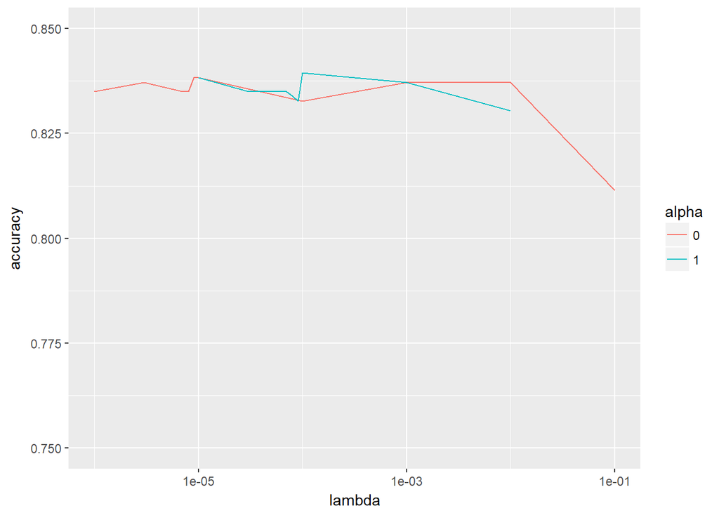

```r
# create data frame with all parameters and their accuracy
results <- data.frame(alpha = as.factor(c(rep(0, length(lambda0)), rep(1, length(lambda1)))),
                      lambda = c(lambda0, lambda1),
                      accuracy = c(accuracyAlpha0, accuracyAlpha1))

ggplot(results, aes(x = lambda, y = accuracy, color = alpha)) + geom_line() + scale_x_log10() + ylim(c(0.75, 0.85))
```

The highest accuracy was found for alpha = 1 and lambda = 1e-4. Since the accuracies between alpha = 0 and 1 were very similar, I did not optimise the parameter alpha.

Finally I train a model with the optimised parameters on the whole training data and make a prediction to be submitted.

```r
predictionTest <- predictSurvIt(passenger, p1 = 1, p2 = 1e-4, nFold = 0)
survivalTest <- predictionTest$final$test[[1]]

# create data frame for submission
solutionLogReg <- data.frame(PassengerId = passenger$PassengerId[passenger$DataSet == "Test"], Survived = survivalTest)
# submit prediction
write.csv(solutionLogReg, "solutionLogReg.csv", row.names=FALSE)
```

The accuracy of this predictor on the test set is 0.80861 - seems like there is some overfitting on the validation set.

## 3.2 K-Nearest Neighbour

Next, I try a the K-Nearest Neighbur predictor. Therefore, I replace the logistics regressions predictor in the functions fitModel and modelPredict by the nearest neighbor classifier knn. As knn is making predictions directly without creating a model, the function fitModel is only used to broadcast all variables to modelPredict.

```r
# function to fit knn
fitModel <- function(X, y, p1, p2){
    list("XTrain" = X, "yTrain" = y, "k" = p1)
}

# function to use model to predict survival
modelPredict <- function(model, X){
    as.numeric(knn(model$XTrain, X, model$yTrain, k = model$k)) - 1
}
```

I make the first prediction with 5 neighbors:

```r
# make first prediction with 5 nearest neighbors
set.seed(0)
prediction <- predictSurvIt(passenger, p1 = 5, p2 = NULL)

accuracyInitial <- predictionAccuracy(prediction$initial, prediction$survivalTrain, prediction$survivalVal)
accuracyFinal <- predictionAccuracy(prediction$final, prediction$survivalTrain, prediction$survivalVal)

writeLines("Initial Prediction Accuracy:")
```

```
## Initial Prediction Accuracy:
```

```r
writeLines(paste("Training:", paste(as.character(round(accuracyInitial$train, 5)), collapse = ", ")))
```

```
## Training: 0.86115, 0.85835, 0.86816, 0.85694, 0.86096
```

```r
writeLines(paste("Validation:", paste(as.character(round(accuracyInitial$val, 5)), collapse = ", ")))
```

```
## Validation: 0.78652, 0.82022, 0.82022, 0.76404, 0.81564
```

```r
writeLines("Final Prediction Accuracy:")
```

```
## Final Prediction Accuracy:
```

```r
writeLines(paste("Training:", paste(as.character(round(accuracyFinal$train, 5)), collapse = ", ")))
```

```
## Training: 0.87377, 0.87097, 0.87938, 0.86676, 0.86517
```

```r
writeLines(paste("Validation:", paste(as.character(round(accuracyFinal$val, 5)), collapse = ", ")))
```

```
## Validation: 0.78652, 0.83708, 0.82584, 0.80899, 0.82123
```

The results are almost identical to logistic regression: the average accuracy over all validation sets of the initial prediction is 80.1% while the final prediction has an average accuracy of 81.6%. However, in contrast to logistic regression, there is only one validation set (set 4) for which the accuracy could be signifantly improve by 4.5% while the accuracy of sets 1, 3, and 5 almost remained the same. Next I change the number of neighors parameter between 5 and 29 (only odd numbers are chosen as knn is making majority votes among the nearest neighbors and even numbers could lead to draws) to find out which value gives the highest accuracy.

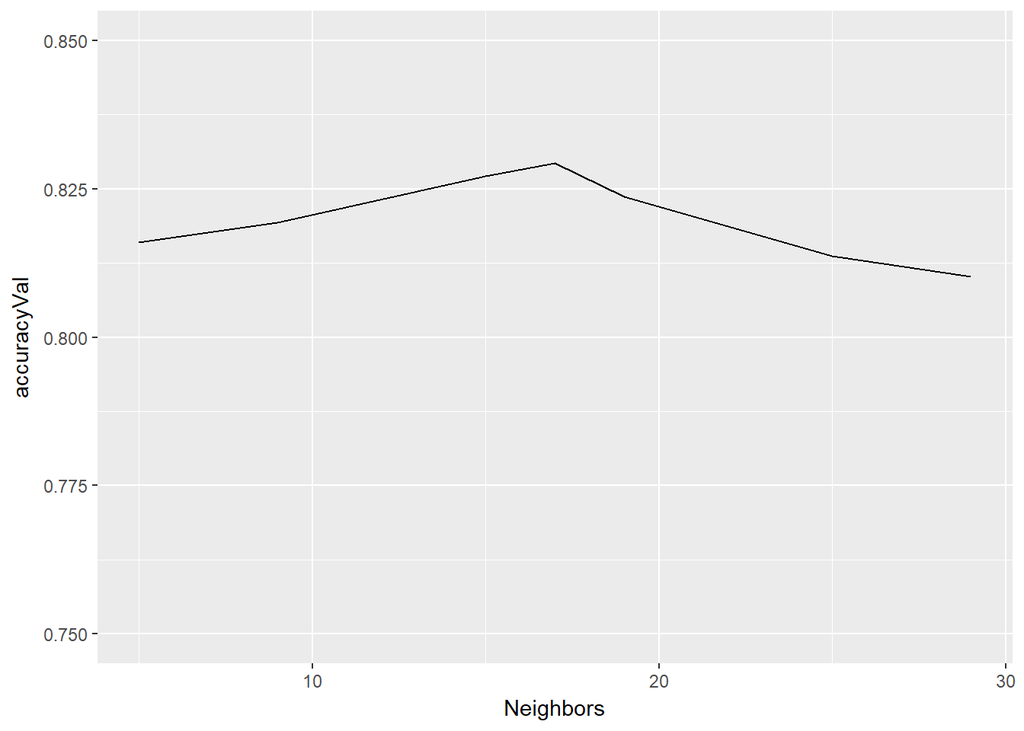

```r
# to save calculation time this line is out commented
# resultGrid <- gridSearchP12(passenger, c(5, 9, 15, 17, 19, 25, 29), NA)

resultGrid <- data.frame(p1 = c(5, 9, 15, 17, 19, 25, 29),
                         p2 = rep(NA, 7),
                         accuracyVal = c(0.8159312, 0.8192957, 0.8271232, 0.8293641, 0.8237462, 0.8136275, 0.8102567))

ggplot(resultGrid, aes(x = p1, y = accuracyVal)) + geom_line() + ylim(c(0.75, 0.85)) + xlab("Neighbors")
```

The highest accuracy on the validation data is 82.9% found for 17 neighbors which is 1% lower than the best result of the logistic regression. Thus, it is expectable that the accracy on the test data with knn will be lower as well.

```r
predictionTest <- predictSurvIt(passenger, p1 = 17, p2 = NULL, nFold = 0)
survivalTest <- predictionTest$final$test[[1]]

# create data frame for submission
solutionKnn <- data.frame(PassengerId = passenger$PassengerId[passenger$DataSet == "Test"], Survived = survivalTest)
# submit prediction
write.csv(solutionKnn, "solutionKnn.csv", row.names=FALSE)
```

The score on the test set is only 77.5%, thus I assume that KNN is clearly overfitting.

## 3.3 Naive Bayes

The main idea of naive bayes is to multiply several probabilities whereby each probability is subject to only one feature to predict to probability of the output class. The problem here is that it can happen that one probability may be 0 so that the product of all probabilities is 0 as well. This can be problematic as other probabilities in this product could be very high and should be an idicator that there should be a significant overall probability for a specific class. To overcome this problem, there is a smoothing parameter k, called laplace smoothing which can avoid that any probability of the product is 0 and therewith ensure that the overall probability is greater than 0 in any case. The higher the value of k the more similar probabilities can become, while a value of 0 disables smoothing completely. I will test a few different values of k to find out which one promises the highest accuracy.

First, I need to update the training and prediction functions to use naive bayes. To apply the laplace parameter I have to convert all categorical features to factors

```r
# this function converts the input arrays to data frames while categorical features are represented by factor variables
# this is certainly slows down the model signigifantly but I did not want to make changes on the pervious functions
matrixToDf <- function(X, y = NULL){
    # number of columns
    nCol <- ncol(X)
    df <- data.frame(X)

    # check if column shall be converted to factor
    for (i in 1:nCol){
        if (all(unique(df[, i]) %in% c(0, 1))){
            df[, i] <- as.factor(df[, i])
        }

    }

    # check if survival shall be added
    if (!is.null(y)){
        df$y <- as.factor(y)
    }

    df
}

# function to fit Naive Bayes
fitModel <- function(X, y, p1, p2){
    # convert input data to data frame
    df <- matrixToDf(X, y)

    # create model
    naiveBayes(y ~ ., data = df, laplace = p1)
}

# function to use model to predict survival
modelPredict <- function(model, X){
    # convert input data to data frame
    df <- matrixToDf(X)

    as.numeric(predict(model, df)) - 1
}
```

Now I make the first prediction by setting k to 1:

```r
# make first prediction with naive bayes
set.seed(0)
prediction <- predictSurvIt(passenger, p1 = 1, p2 = NULL)

accuracyInitial <- predictionAccuracy(prediction$initial, prediction$survivalTrain, prediction$survivalVal)
accuracyFinal <- predictionAccuracy(prediction$final, prediction$survivalTrain, prediction$survivalVal)


writeLines("Initial Prediction Accuracy:")
```

```
## Initial Prediction Accuracy:
```

```r
writeLines(paste("Training:", paste(as.character(round(accuracyInitial$train, 5)), collapse = ", ")))
```

```
## Training: 0.78401, 0.79663, 0.7798, 0.78682, 0.77669
```

```r
writeLines(paste("Validation:", paste(as.character(round(accuracyInitial$val, 5)), collapse = ", ")))
```

```
## Validation: 0.77528, 0.73034, 0.75843, 0.79213, 0.82682
```

```r
writeLines("Final Prediction Accuracy:")
```

```
## Final Prediction Accuracy:
```

```r
writeLines(paste("Training:", paste(as.character(round(accuracyFinal$train, 5)), collapse = ", ")))
```

```
## Training: 0.80224, 0.79804, 0.76157, 0.76718, 0.77388
```

```r
writeLines(paste("Validation:", paste(as.character(round(accuracyFinal$val, 5)), collapse = ", ")))
```

```
## Validation: 0.79213, 0.75843, 0.73596, 0.79213, 0.79888
```

The average accuracy of the final prediction on the validation set is 77.6%. This is clearly worse than logistic regression and KNN which should be mainly due to the fact that the used features are correlated. Another problem of naive bayes could be that all features have the same impact on the output. As this data set contains a lot of features with different importance, this could be another reason for the poor performance of naive bayes. There is almost no difference in the accuracy between the initial and the final prediction.

To make sure that this result is not caused due to a bad choice of the laplace parameter, I do a grid search with different values.

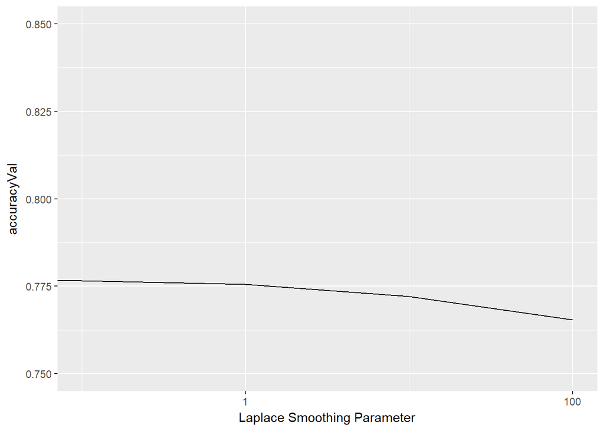

```r
# to save time I outcommented this line
# resultGrid <- gridSearchP12(passenger, c(0, 0.1, 1, 10, 100), NA)

# these are the results of the calculation
resultGrid <- data.frame(p1 = c(0, 0.1, 1, 10, 100),
                         p2 = rep(NA, 5),
                         accuracyVal = c(0.776630468897119, 0.776630468897119, 0.775506873391501, 0.772142363944511, 0.765400790910803))

ggplot(resultGrid, aes(x = p1, y = accuracyVal)) + geom_line() + xlab("Laplace Smoothing Parameter") + scale_x_log10() + ylim(c(0.75, 0.85))
```

Interestingly, the highest accuracy is reached with a smooting parameter of 0 which means that no smoothing should be done at all. Although I tried a wide range of smoothing parameters, the accuracy still remains significantly lower than that of the other classifiers I have tried yet.

To complete this section I make a prediction on the test set to get the test score of the naive bayes classifier.

```r
predictionTest <- predictSurvIt(passenger, p1 = 0, p2 = NULL, nFold = 0)
survivalTest <- predictionTest$final$test[[1]]

# create data frame for submission
solutionNB <- data.frame(PassengerId = passenger$PassengerId[passenger$DataSet == "Test"], Survived = survivalTest)
# submit prediction
write.csv(solutionNB, "solutionNB.csv", row.names=FALSE)
```

As expected the accuracy on the test set with this classifier was really low with only 74.6%.

## 3.4 Decision Tree

Next, I try decision tree. Decision trees can handle categorical and continius features very well and in contrast to KNN and naive bayes are also able to identify which features are important and weight these accordingly. Thus, I am expecting that decision trees will be better than KNN and naive bayes. The downside of decision trees is that they are prone to overfitting. Thus, I am sure that random forest will outperform decision trees.

There are many parameters which can be tuned to reduce the danger overfitting. In this kernel I will only consider the minimum number of observations in order to further split a node (minsplit) and the maximum depth of the tree (maxdepth).

Again I update the fit and predict functions to use decision trees:

```r
# function to fit decision tree
fitModel <- function(X, y, p1, p2){
    # convert matrix data data frame
    df <- data.frame(X)
    df$y <- y

    # set hyper-parameter
    control <- rpart.control(minsplit = p1, maxdepth = p2, cp = 0, maxcompete = 1, maxsurrogate = 1, xval = 1)
    # create model
    rpart(y ~., data = df, method = "class", control = control)
}

# function to use model to predict survival
modelPredict <- function(model, X){
    # convert matrix data data frame
    df <- data.frame(X)

    as.numeric(predict(model, df, type = "class")) - 1
}
```

Now I make my first prediction with a simple model with a depth of 5 having at least 10 observations in each node to make a further split.

```r
# make first prediction with decision trees.
set.seed(0)
prediction <- predictSurvIt(passenger, p1 = 10, p2 = 5)

accuracyInitial <- predictionAccuracy(prediction$initial, prediction$survivalTrain, prediction$survivalVal)
accuracyFinal <- predictionAccuracy(prediction$final, prediction$survivalTrain, prediction$survivalVal)

writeLines("Initial Prediction Accuracy:")
```

```
## Initial Prediction Accuracy:
```

```r
writeLines(paste("Training:", paste(as.character(round(accuracyInitial$train, 5)), collapse = ", ")))
```

```
## Training: 0.87237, 0.87237, 0.88079, 0.87798, 0.85955
```

```r
writeLines(paste("Validation:", paste(as.character(round(accuracyInitial$val, 5)), collapse = ", ")))
```

```
## Validation: 0.81461, 0.81461, 0.79213, 0.82584, 0.86592
```

```r
writeLines("Final Prediction Accuracy:")
```

```
## Final Prediction Accuracy:
```

```r
writeLines(paste("Training:", paste(as.character(round(accuracyFinal$train, 5)), collapse = ", ")))
```

```
## Training: 0.86396, 0.86396, 0.87377, 0.86957, 0.85393
```

```r
writeLines(paste("Validation:", paste(as.character(round(accuracyFinal$val, 5)), collapse = ", ")))
```

```
## Validation: 0.8427, 0.78652, 0.83146, 0.83146, 0.86592
```

Now I do a grid search on minsplit and maxdepth to find the best hyper-parameter combination.

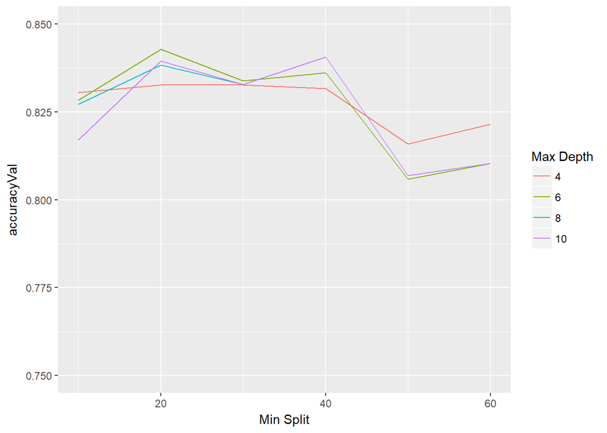

```r
minsplit <- c(10, 20, 30, 40, 50, 60)
maxdepth <- c(4, 6, 8, 10)

# to save time I outcommented this line
# resultGrid <- gridSearchP12(passenger, minsplit, maxdepth)
resultGrid <- data.frame(p1 = rep(minsplit, length(maxdepth)),
                         p2 = rep(maxdepth, each = length(minsplit)),
                         accuracyVal = c(0.830506559538008, 0.832728642269788, 0.832734919339652, 0.831611323834034, 0.815899817964974, 0.821517795493064,
                                      0.828278199736363, 0.842847278890214, 0.833883623124725, 0.836124537066098, 0.805812566693867, 0.810306948716339,
                                      0.82712949595129,  0.838352896867742, 0.832760027619107, 0.840600087878978, 0.806936162199485, 0.810306948716339,
                                      0.817010859330864, 0.839470215303496, 0.832760027619107, 0.840600087878978, 0.806936162199485, 0.810306948716339))

ggplot(resultGrid, aes(x = p1, y = accuracyVal, color = as.factor(p2))) +
    geom_line() +
    ylim(c(0.75, 0.85)) +
    xlab("Min Split") +
    labs(color = "Max Depth")
```

The graph shows that trees with a maximum depth between 6 and 10 and minimum split between 20 and 40 performed best. The highest accuracy was 84.3% with maximum depth of 6 and minimum split of 20. Trees with a maximum depth of 4 are obviously underfitting. The accuracy of trees with a higher depth converge to the same value for the highest number of minimum splits as these trees do not reach their maximum depth before nodes are not allowed to be split further due to the high number of minsplit - it is expectable that all these trees are identical.

Finally, I make a prediction with the best parameters to predict survival on the test set.

```r
predictionTest <- predictSurvIt(passenger, p1 = 20, p2 = 6, nFold = 0)
survivalTest <- predictionTest$final$test[[1]]

# create data frame for submission
solutionDecisionTree <- data.frame(PassengerId = passenger$PassengerId[passenger$DataSet == "Test"], Survived = survivalTest)
# submit prediction
write.csv(solutionDecisionTree, "solutionDecisionTree.csv", row.names = FALSE)
```

The score on the test set with this prediction is 79.4%. Thus, there is a massive decrease in accuracy of almost 5%. I think the reason for that is that I treid many different parameter values a therewith substantially overfitted on the validation data set.

Another option to tune the parameters of decision tree is to use the complexity parameter cp. This parameter defines the by how much the objective function must be improved after splitting a node. If this is not achieved the respective node will not be split and other nodes are checked. Once no node is left to be split the algorithm is finished. I redefine the fit function to use this parameter. In order to use this parameter only I set minsplit to 2 and maxdepth to 30 so that these parameter have no effect anymore.

```r
# function to fit decision tree
fitModel <- function(X, y, p1, p2){
    # convert matrix data data frame
    df <- data.frame(X)
    df$y <- y

    # set hyper-parameter
    control <- rpart.control(minsplit = 2, maxdepth = 30, cp = p1, maxcompete = 1, maxsurrogate = 1, xval = 1)
    # create model
    rpart(y ~., data = df, method = "class", control = control)
}
```

Let’s make a prediction with the default value of cp which is 0.01.

```r
# make first prediction with decision trees
set.seed(0)
prediction <- predictSurvIt(passenger, p1 = 0.01, p2 = NA)

accuracyInitial <- predictionAccuracy(prediction$initial, prediction$survivalTrain, prediction$survivalVal)
accuracyFinal <- predictionAccuracy(prediction$final, prediction$survivalTrain, prediction$survivalVal)

writeLines("Initial Prediction Accuracy:")
```

```
## Initial Prediction Accuracy:
```

```r
writeLines(paste("Training:", paste(as.character(round(accuracyInitial$train, 5)), collapse = ", ")))
```

```
## Training: 0.85554, 0.85975, 0.86396, 0.87377, 0.83989
```

```r
writeLines(paste("Validation:", paste(as.character(round(accuracyInitial$val, 5)), collapse = ", ")))
```

```
## Validation: 0.82584, 0.83146, 0.82022, 0.82584, 0.88827
```

```r
writeLines("Final Prediction Accuracy:")
```

```
## Final Prediction Accuracy:
```

```r
writeLines(paste("Training:", paste(as.character(round(accuracyFinal$train, 5)), collapse = ", ")))
```

```
## Training: 0.86255, 0.85133, 0.85554, 0.87798, 0.82303
```

```r
writeLines(paste("Validation:", paste(as.character(round(accuracyFinal$val, 5)), collapse = ", ")))
```

```
## Validation: 0.83146, 0.79775, 0.85393, 0.82584, 0.87709
```

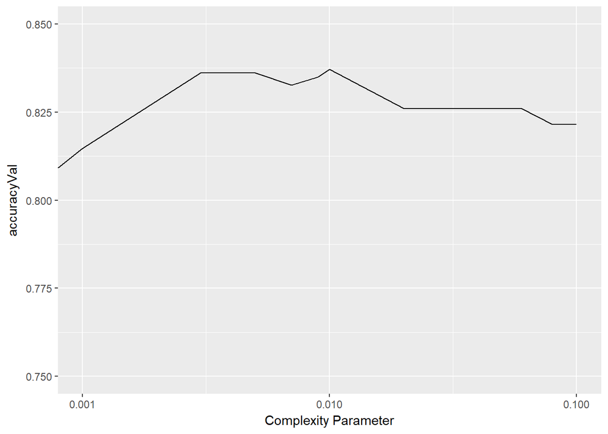

```r
cp <- c(0, 0.001, 0.003, 0.005, 0.007, 0.009, 0.01, 0.02, 0.04, 0.06, 0.08, 0.1)

# to save time I outcommented this line
#resultGrid <- gridSearchP12(passenger, cp, NA)
resultGrid <- data.frame(p1 = cp,
                         p2 = rep(NA, length(cp)),
                         accuracyVal = c(0.809133136651811, 0.814751114179901, 0.836093151716779, 0.83611198292637, 0.832741196409516, 0.834982110350888,
                                      0.837216747222397, 0.825980792166217, 0.825980792166217, 0.825980792166217, 0.821486410143745, 0.821486410143745))

ggplot(resultGrid, aes(x = p1, y = accuracyVal)) + geom_line() + xlab("Complexity Parameter") + scale_x_log10() + ylim(c(0.75, 0.85))
```

It turned out that 0.01 is actually the best parameter value. Thus, I higher accuracy on the validation sets than 83.7% seems not to be possible. When cp is smaller, the too many nodes are split so that the model is overfitting while higher values lead to uderfitting. There are some plateaus at the right side of the graph where the accuracy did not change while increasing cp. This can be explained that in this area the change of cp is so small that exactly the same trees are created. As this is worse than the validation error with minsplit and maxdepth I am not making a submission with this model.

## 3.5 Support Vector Machines

Next I try Support Vector Machines (SVM). This classifier is certainly more complex than all the others which I tried so far, so let’s see if it is possible to improve accuracy.

There are quite a lot of parameters which can be tuned. For this notebook I focus on the radial kernel and the parameters C and gamma. The kernel is actually a function which is used to calculate the similarity of two training examples with respect to their distance. Gamma is a parameter within the kernel which can be used for scaling. The higher gamma is, the more similar training examples are considered which are far away from each other. The parameter C is a meassure how strong misclassifications are penalised. A low value of C causes a lower penalty so that the decision surface becomes smoother.

Again, I update the fit and predict functions to use SVM and tune the parameters later.

```r
# function to fit SVM
fitModel <- function(X, y, p1, p2){
    # create model
    svm(X, as.factor(y), scale = FALSE, kernel = "radial", gamma = p1, cost = p2)
}

# function to use model to predict survival
modelPredict <- function(model, X){
    as.numeric(predict(model, X)) - 1
}
```

First, I make a prediction where gamma and C are set to 1 (default values).

```r
# make first prediction with SVM
set.seed(0)
prediction <- predictSurvIt(passenger, p1 = 1, p2 = 1)

accuracyInitial <- predictionAccuracy(prediction$initial, prediction$survivalTrain, prediction$survivalVal)
accuracyFinal <- predictionAccuracy(prediction$final, prediction$survivalTrain, prediction$survivalVal)

writeLines("Initial Prediction Accuracy:")
```

```
## Initial Prediction Accuracy:
```

```r
writeLines(paste("Training:", paste(as.character(round(accuracyInitial$train, 5)), collapse = ", ")))
```

```
## Training: 0.87377, 0.87798, 0.86957, 0.87658, 0.86657
```

```r
writeLines(paste("Validation:", paste(as.character(round(accuracyInitial$val, 5)), collapse = ", ")))
```

```
## Validation: 0.76404, 0.79775, 0.81461, 0.78652, 0.86034
```

```r
writeLines("Final Prediction Accuracy:")
```

```
## Final Prediction Accuracy:
```

```r
writeLines(paste("Training:", paste(as.character(round(accuracyFinal$train, 5)), collapse = ", ")))
```

```
## Training: 0.88499, 0.8892, 0.87798, 0.8864, 0.87921
```

```r
writeLines(paste("Validation:", paste(as.character(round(accuracyFinal$val, 5)), collapse = ", ")))
```

```
## Validation: 0.80337, 0.79775, 0.80899, 0.82022, 0.87709
```

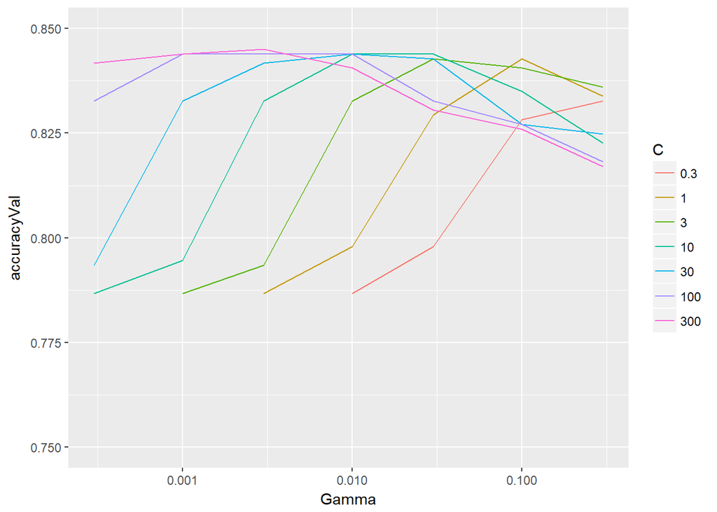

```r
gamma <- c(0.0003, 0.001, 0.003, 0.01, 0.03, 0.1, 0.3)
C <- c(0.3, 1, 3, 10, 30, 100, 300)

# to save time I outcommented this line
#resultGrid <- gridSearchP12(passenger, gamma, C)
resultGrid <- data.frame(p1 = rep(gamma, length(C)),
                         p2 = rep(C, each = length(gamma)),
                         accuracyVal = c(0.616169731969117, 0.616169731969117, 0.686836984495637, 0.786705166028498, 0.797916012805223, 0.828221706107589, 0.832716088130061,
                                      0.616169731969117, 0.726150273052539, 0.786705166028498, 0.797916012805223, 0.829345301613207, 0.842828447680623, 0.833833406565815,
                                      0.691318812378382, 0.786705166028498, 0.793427907852614, 0.832716088130061, 0.842828447680623, 0.840574979599523, 0.836080597577051,
                                      0.786705166028498, 0.794551503358232, 0.832716088130061, 0.843952043186241, 0.843952043186241, 0.834950725001569, 0.822628836858954,
                                      0.793427907852614, 0.832716088130061, 0.841704852175005, 0.843952043186241, 0.842822170610759, 0.827116941811562, 0.824869750800326,
                                      0.832716088130061, 0.843952043186241, 0.843952043186241, 0.843952043186241, 0.832703533990333, 0.827135773021154, 0.818128177766619,
                                      0.841704852175005, 0.843952043186241, 0.845075638691859, 0.840568702529659, 0.830481451258553, 0.825993346305944, 0.817017136400728))

ggplot(resultGrid, aes(x = p1, y = accuracyVal, color = as.factor(p2))) +
    geom_line() +
    ylim(c(0.75, 0.85)) +
    xlab("Gamma") +
    labs(color = "C") +
    scale_x_log10()
```

```r
predictionTest <- predictSurvIt(passenger, p1 = 0.003, p2 = 300, nFold = 0)
survivalTest <- predictionTest$final$test[[1]]

# create data frame for submission
solutionSVM <- data.frame(PassengerId = passenger$PassengerId[passenger$DataSet == "Test"], Survived = survivalTest)
# submit prediction
write.csv(solutionSVM, "solutionSVM.csv", row.names = FALSE)
```

The score on the test set is 79.4% which is exactly the same as with decision trees. Due to the big difference to the validation accuracy it looks like SVC is overfitting as well.

## 3.6 Random Forest

The next classifier I try is random forest. There are a lot of different hyperparameters which can be tuned. I will focus on ntree - total number of trees, mtry - number of randomly sampled variables for each split, and maxnodes - maximum number of nodes a tree can have.

First of all I need to update the fit and predict functions:

```r
# function to fit Random Forest
fitModel <- function(X, y, p1, p2){
    # create model
    randomForest(X, as.factor(y), ntree = p1, mtry = 10, maxnodes = p2)
}

# function to use model to predict survival
modelPredict <- function(model, X){
    as.numeric(predict(model, X)) - 1
}
```

For the first run I set the number of trees to 50 and limit the maximum number of nodes to 12.

```r
# make first prediction with Random Forest
set.seed(0)
prediction <- predictSurvIt(passenger, p1 = 50, p2 = 12)

accuracyInitial <- predictionAccuracy(prediction$initial, prediction$survivalTrain, prediction$survivalVal)
accuracyFinal <- predictionAccuracy(prediction$final, prediction$survivalTrain, prediction$survivalVal)

writeLines("Initial Prediction Accuracy:")
```

```
## Initial Prediction Accuracy:
```

```r
writeLines(paste("Training:", paste(as.character(round(accuracyInitial$train, 5)), collapse = ", ")))
```

```
## Training: 0.83871, 0.84151, 0.8345, 0.84151, 0.82584
```

```r
writeLines(paste("Validation:", paste(as.character(round(accuracyInitial$val, 5)), collapse = ", ")))
```

```
## Validation: 0.82584, 0.80899, 0.8427, 0.81461, 0.87709
```

```r
writeLines("Final Prediction Accuracy:")
```

```
## Final Prediction Accuracy:
```

```r
writeLines(paste("Training:", paste(as.character(round(accuracyFinal$train, 5)), collapse = ", ")))
```

```
## Training: 0.85273, 0.85835, 0.84853, 0.84853, 0.83848
```

```r
writeLines(paste("Validation:", paste(as.character(round(accuracyFinal$val, 5)), collapse = ", ")))
```

```
## Validation: 0.82584, 0.80337, 0.83708, 0.83708, 0.88268
```

Before I tune mtry and maxnodes I start with ntree. I expect there is no optimum number of trees - the higher this number the better the accuracy. However, the accuracy will saturate so that at some having more trees will unnecessarily increase compution time.

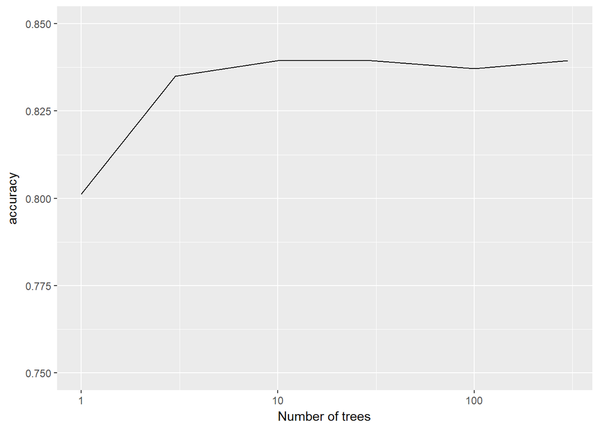

```r
nTree <- c(1, 3, 10, 30, 100, 300)

# to save time I outcommented this line
#resultGrid <- gridSearchP12(passenger, nTree, 12)
resultGrid <- data.frame(p1 = nTree,
                         p2 = rep(12, length(nTree)),
                         accuracy = c(0.801274245182349, 0.834963279141297, 0.839482769443224, 0.839463938233633, 0.837210470152533, 0.839457661163769))

ggplot(resultGrid, aes(x = p1, y = accuracy)) + geom_line() + xlab("Number of trees") + scale_x_log10() + ylim(c(0.75, 0.85))
```

It looks that 30 trees are more than enough, so I will use this number of a further predictions. Next, I optimise mtry and maxnodes.

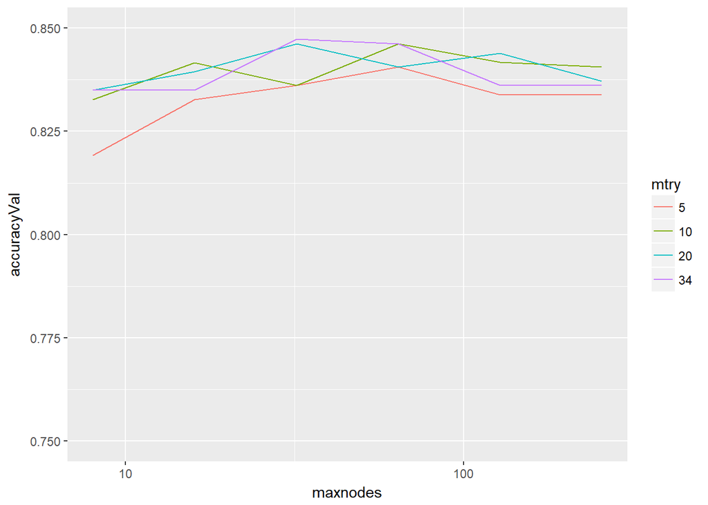

```r
# update function to fit Random Forest
fitModel <- function(X, y, p1, p2){
    # create model
    randomForest(X, as.factor(y), ntree = 30, mtry = p1, maxnodes = p2)
}

mtry <- c(5, 10, 20, 34)
maxnodes <- c(8, 16, 32, 64, 128, 256)

#resultGrid <- gridSearchP12(passenger, mtry, maxnodes)
resultGrid <- data.frame(p1 = rep(mtry, length(maxnodes)),
                         p2 = rep(maxnodes, each = length(mtry)),
                         accuracyVal = c(0.819239219132509, 0.832722365199925, 0.834963279141297, 0.834963279141297,
                                      0.832716088130061, 0.841692298035277, 0.839445107024041, 0.834963279141297,
                                      0.836093151716779, 0.836093151716779, 0.846174125918021, 0.847322829703095,
                                      0.840574979599523, 0.846199234197477, 0.840581256669387, 0.846192957127613,
                                      0.833845960705543, 0.841698575105141, 0.843939489046513, 0.836099428786642,
                                      0.833845960705543, 0.840562425459795, 0.837216747222397, 0.836099428786642))

ggplot(resultGrid, aes(x = p2, y = accuracyVal, color = as.factor(p1))) +
    geom_line() +
    ylim(c(0.75, 0.85)) +
    xlab("maxnodes") +
    labs(color = "mtry") +
    scale_x_log10()
```

The maximum number of nodes does not seem to have a big effect on the accuracy, values between 16 and 256 reach similar accuracies. Regarding mtry, the graph shows that 5 performs worse than higher numbers, while the others are fluctuating so that there is no number which is clearly the best. The parameter set which reached the highest accuracy of 84.7% was with mtry = 34 and maxnodes = 32. I will use these parameters for the prediction on the test set.

Since the optimised parameters are quite far away from the parameters I used to decide how many trees are needed, I run the grid search regarding the number of trees again. Therefore, I use the model with the highest complexity - mtry = 34 and maxnodes = 256.

[figure not shown]

```r
# update function to fit Random Forest
fitModel <- function(X, y, p1, p2){
    # create model
    randomForest(X, as.factor(y), ntree = p1, mtry = 34, maxnodes = p2)
}

nTree <- c(1, 3, 10, 30, 100, 300, 1000)

# to save time I outcommented this line
#resultGrid <- gridSearchP12(passenger, nTree, 256)
#resultGrid <- data.frame(p1 = nTree,
#                         p2 = rep(50, length(nTree)),
#                         accuracyVal = c(0.768752746218065, 0.799027054171113, 0.832709811060197, 0.836099428786642, 0.827110664741699, 0.834957002071433, 0.834963279141297))

ggplot(resultGrid, aes(x = p1, y = accuracyVal)) + geom_line() + xlab("Number of trees") + scale_x_log10() + ylim(c(0.75, 0.85))
```

Now I make a prediction for the test set.

```r
# update function to fit Random Forest
fitModel <- function(X, y, p1, p2){
    # create model
    randomForest(X, as.factor(y), ntree = 30, mtry = p1, maxnodes = p2)
}

predictionTest <- predictSurvIt(passenger, p1 = 34, p2 = 32, nFold = 0)
survivalTest <- predictionTest$final$test[[1]]

# create data frame for submission
solutionRandomForest <- data.frame(PassengerId = passenger$PassengerId[passenger$DataSet == "Test"], Survived = survivalTest)
# submit prediction
write.csv(solutionRandomForest, "solutionRandomForest.csv", row.names = FALSE)

# public score: 0.76555
```

The public score is only 76.6% which is again much lower than validation accuracy of 84.7%. It is diffcult to say what causes these differences. Maybe the used models are too complex and the number of used features is too high.

Let’s have a look at the training and validation error of this prediction:

```r
# make first prediction with Random Forest
set.seed(0)
prediction <- predictSurvIt(passenger, p1 = 34, p2 = 32)

accuracyInitial <- predictionAccuracy(prediction$initial, prediction$survivalTrain, prediction$survivalVal)
accuracyFinal <- predictionAccuracy(prediction$final, prediction$survivalTrain, prediction$survivalVal)

writeLines("Initial Prediction Accuracy:")
```

```
## Initial Prediction Accuracy:
```

```r
writeLines(paste("Training:", paste(as.character(round(accuracyInitial$train, 5)), collapse = ", ")))
```

```
## Training: 0.90463, 0.89762, 0.90463, 0.90042, 0.89045
```

```r
writeLines(paste("Validation:", paste(as.character(round(accuracyInitial$val, 5)), collapse = ", ")))
```

```
## Validation: 0.84831, 0.82584, 0.83708, 0.81461, 0.88827
```

```r
writeLines("Final Prediction Accuracy:")
```

```
## Final Prediction Accuracy:
```

```r
writeLines(paste("Training:", paste(as.character(round(accuracyFinal$train, 5)), collapse = ", ")))
```

```
## Training: 0.90884, 0.91445, 0.91304, 0.91725, 0.9073
```

```r
writeLines(paste("Validation:", paste(as.character(round(accuracyFinal$val, 5)), collapse = ", ")))
```

```
## Validation: 0.83146, 0.82584, 0.8427, 0.83708, 0.89385
```

First of all, lets have a look how the training accuracy changes with the number of trees.

```r
# update function to fit Random Forest
fitModel <- function(X, y, p1, p2){
    # create model
    randomForest(X, as.factor(y), ntree = p1, mtry = 34, maxnodes = p2)
}

nTree <- c(1, 3, 10, 30, 100, 300, 1000)

# to save time I outcommented this line
#resultGrid <- gridSearchP12(passenger, nTree, 256)
resultGrid <- data.frame(p1 = nTree,
                         p2 = rep(50, length(nTree)),
                         accuracyTrain = c(0.912173991836992, 0.95651188994122, 0.979518414044156, 0.991020691176702, 0.995791638432324, 0.995791638432324, 0.995791638432324),
                         accuracyVal = c(0.768752746218065, 0.799027054171113, 0.832709811060197, 0.836099428786642, 0.827110664741699, 0.834957002071433, 0.834963279141297))
```

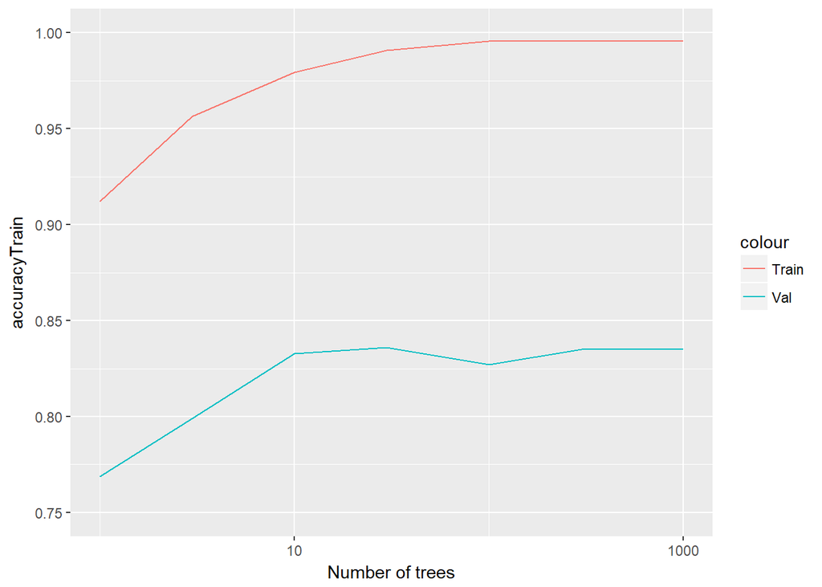

```r
ggplot(resultGrid, aes(x = p1)) +
    geom_line(aes(y = accuracyTrain, colour = "Train")) +
    geom_line(aes(y = accuracyVal, colour = "Val")) +
    xlab("Number of trees") +
    scale_x_log10() +
    ylim(c(0.75, 1))
```

One very simple way could be to subtract the difference between training and validation accuracy from the validation accuracy or to define a maximum threshold for the difference between training and validation accuracy which must not be exceeded. I will try this in the next step.